# RNASeqRData : RNASeqR vignette sample data explanation

Author: Kuan-Hao Chao (ntueeb05howard@gmail.com)

Last update: 16 October, 2018

# 1 Introduction

RNASeqRData is a helper package for vignette in RNASeqR software package. This vignette shows the criteria of `input_files` and extraction process of mini example data.

# 2 `input_files` criteria

`input.path.prefix` is the parameter that stores the directory location of *‘input_files/’*. Users have to prepare an *‘input_file/’* before running RNASeqR package workflow. The criteria of *‘input_file/’* are listed below:

- **`genome.name`.fa**: reference genome in FASTA file formation.
- **`genome.name`.gtf**: gene annotation in GTF file formation.
- **raw_fastq.gz/**: directory storing `FASTQ` files.
  - Support paired-end reads files only.
  - Names of paired-end `FASTQ` files : ’`sample.pattern`_1.fastq.gz’ and ’`sample.pattern`_2.fastq.gz’. `sample.pattern` must be distinct for each sample.
- **phenodata.csv**: information about RNA-Seq experiment design.
  - First column : Distinct ids for each sample. Value of each sample of this column must match `sample.pattern` in `FASTQ` files in *‘raw_fastq.gz/’*. Column names must be **ids**.
  - Second column : independent variable for the RNA-Seq experiment. Value of each sample of this column can only be parameter `case.group` and `control.group`. Column name is parameter `independent.variable`.
- **indices/** : directory storing `HT2` indices files for HISAT2 alignment tool.
  - This directory is **optional**. `HT2` indices files corresponding to target reference genome can be installed at [HISAT2 official website](https://ccb.jhu.edu/software/hisat2/index.shtml). Providing `HT2` files can accelerate the subsequent steps. It is highly advised to install `HT2` files.
  - If `HT2` index files are not provided, *‘input_files/indices/’* directory should be deleted.

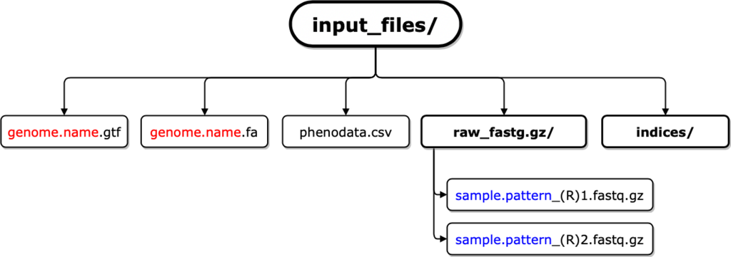

# 3 Sample definition

# 4 Sample data preparation process

- `Saccharomyces_cerevisiae_XV_Ensembl.fa`: Only XV chromosome sequence are extracted.
- `Saccharomyces_cerevisiae_XV_Ensembl.gtf`: The whole *Saccharomyces cerevisiae* gtf annotation files.